# OLS: Outliers

Rebecca Gill

2026-05-17

← Back to Index

This page is built in R Markdown. Most code chunks are hidden by default, but you can click ‘show’ to see the code that loads the libraries and generates the data, figures, and tables. The code is also available in my [studycourts/gradData GitHub repository](https://github.com/studycourts/gradData/tree/main/pages).

```r
library(texreg)       # pretty model tables
library(car)          # helpful summary functions
library(carData)      # data to use with car functions
library(ggcorrplot)   # pretty correlation matrices
library(stargazer)    # pretty tables
library(kableExtra)   # makes kable tables prettier
library(ggeffects)    # to plot predictions from models
library(modelsummary) # pretty tables supporting stan_glm
library(ggeffects)    # for plotting model effects
library(ggiraphExtra) # more model effect plot functions
library(metRology)    # to simulate student's t errors
library(corrtable)    # pretty correlation matrices without the figure
library(outliers)     # outlier detection tools
library(DescTools)    # for winsorizing
library(rstanarm)     # for bayesian models
library(loo)          # to implement leave-one-out cross-validation
library(MASS)         # robust regression methods
library(tidyverse)    # load last to avoid conflicts with other packages

options(scipen = 999) # prevents scientific notation in the output
```

## Introduction

In this document, we’re going to explore outliers and influential observations in regression analysis. An outlier is an observation that falls far away from the rest of the data points. While all influential observations are outliers, not all outliers are influential. Understanding the difference between these types of observations and knowing how to diagnose and handle them is crucial for building robust regression models.

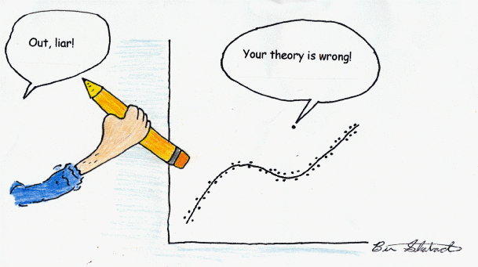

First, I’ll walk you through what outliers are and why they matter. Then, we’ll explore the different types of outliers using simulated data to see how they affect our regression models. Finally, I’ll show you practical diagnostic tools for identifying problematic outliers in real data and discuss strategies for dealing with them.

## Types of Outliers

Outliers can be categorized into three main types based on their characteristics and impact on regression models:

**Regular Outliers** are observations that fall far from the regression line in terms of the Y variable but are not unusual in terms of their X values. These points sit in the middle of the pack relative to X, so while they may have unusual Y values, they don’t pull the regression line much because they lack leverage. Think of these as unexpected outcomes that deviate from what we’d predict, but they’re not in a position to change our overall understanding of the relationship.

**High Leverage Outliers** are unusual in terms of their X values. In the simple bivariate case, this is just an X value that is far outside the norm. In multivariate regression, a high leverage observation might be particularly high or low for one or more predictors, or it might represent an unusual combination of predictor values compared with other observations. Not all high leverage outliers are problematic—some may fall right along the regression line, just at an extreme position.

**Influential Outliers** are the ones we really need to worry about. These are observations that have both unusual X values (high leverage) and pull the regression line away from where it would otherwise be. When we remove an influential outlier and re-estimate the model, we see a meaningful change in our regression coefficients. These are the outliers that can bias our estimates and lead us to incorrect conclusions.

That sounds like it could be bad. Why are some of these so much worse than others?

Great question. Let’s see if I can help you understand why the point that seems the most “out there” in your dataset might *not* be the one you need to worry about the most.

## Visualizing Different Types of Outliers

Let’s use a simulation to see what these different types of outliers look like and how they affect our regression models. We’ll start with a simple linear relationship: $y = 1 + 3x + e$, where $x$ comes from a uniform distribution between 0 and 5, and the error term $e$ is normally distributed with mean 0 and standard deviation 1.

Figure 1: Plot of Simulated Data Without Outliers

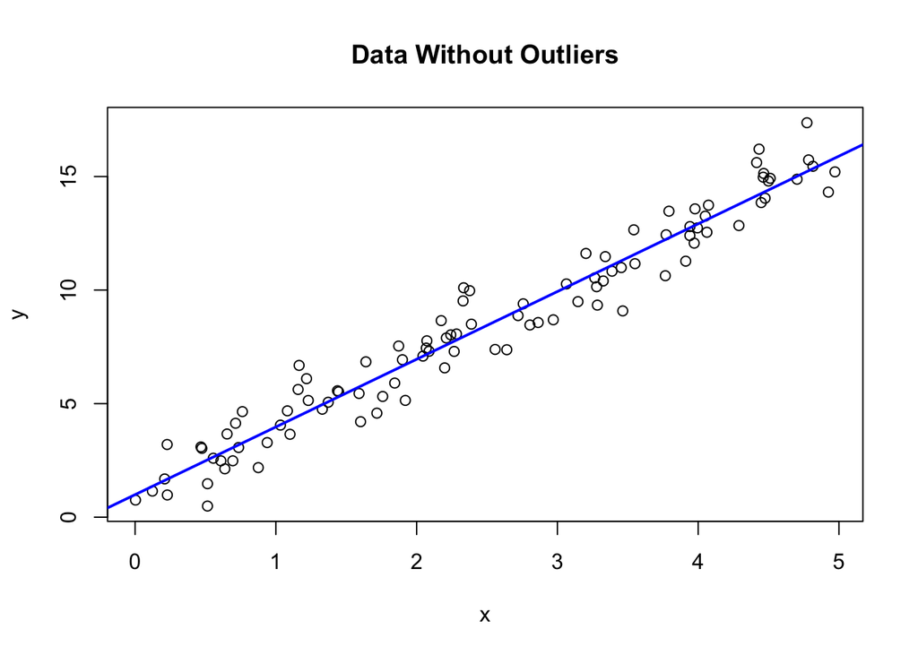

```r
set.seed(123)

n <- 100                        # we want 100 observations
x <- runif(n, 0, 5)             # x from a uniform distribution
y <- 1 + 3*x + rnorm(n, 0, 1)   # calculate y with error

# plot the data
plot(x, y, main = "Data Without Outliers")
abline(lm(y~x), col = "blue", lwd = 2)
```

The plot shows the relationship we’d expect, given how we set up the simulation. Now let’s create three additional versions of our data, each with a different type of outlier added.

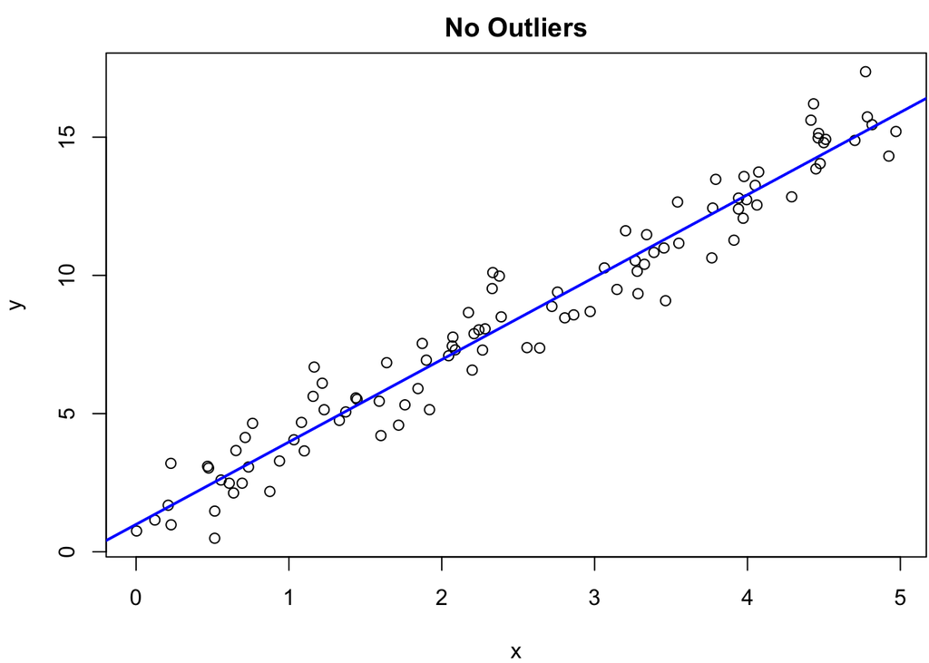

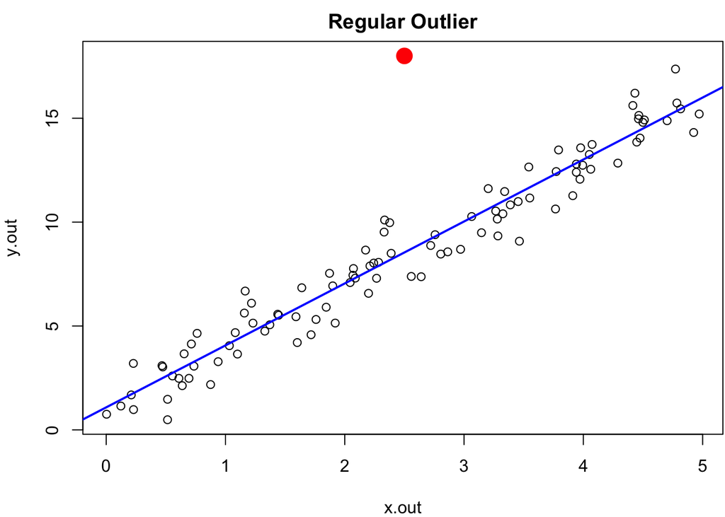

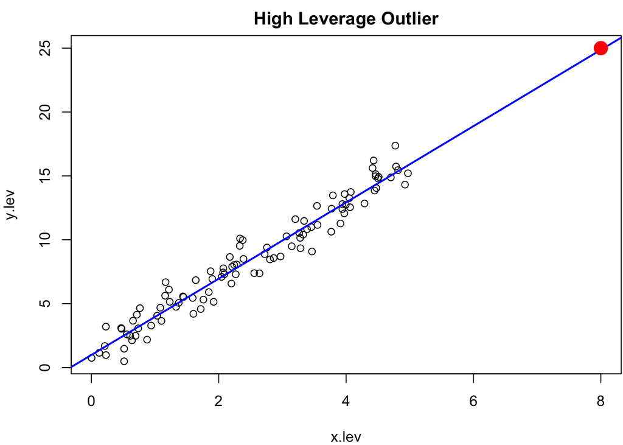

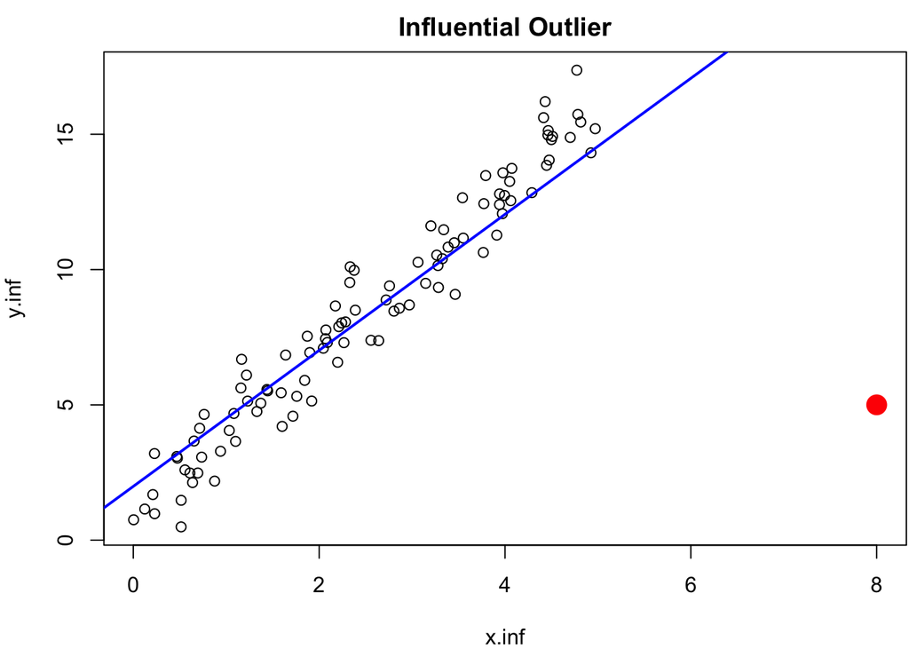

```r
par(mar = c(4, 4, 2, .1))      # set up display space

# Create the different types of outliers
y.out <- c(y, 18)               # regular outlier (unusual Y)
x.out <- c(x, 2.5)              # at a typical X value

y.lev <- c(y, 25)               # high leverage outlier
x.lev <- c(x, 8)                # at an extreme X value, but on the line

y.inf <- c(y, 5)                # influential outlier
x.inf <- c(x, 8)                # at an extreme X value, pulling the line

# Plot all four scenarios
plot(x, y, main = "No Outliers")
abline(lm(y~x), col = "blue", lwd = 2)

plot(x.out, y.out, main = "Regular Outlier")
abline(lm(y.out ~ x.out), col = "blue", lwd = 2)
points(2.5, 18, col = "red", pch = 19, cex = 2)

plot(x.lev, y.lev, main = "High Leverage Outlier")
abline(lm(y.lev ~ x.lev), col = "blue", lwd = 2)
points(8, 25, col = "red", pch = 19, cex = 2)

plot(x.inf, y.inf, main = "Influential Outlier")
abline(lm(y.inf ~ x.inf), col = "blue", lwd = 2)
points(8, 5, col = "red", pch = 19, cex = 2)
```

This all looks neat. But what am I actually looking at?

In the top-right plot, our regular outlier sits at the point (2.5, 18). Although this observation is far from the regression line on the Y axis, it’s near the middle of the pack on the X axis. As you can see, the outlier isn’t pulling at the regression line much, since it’s in the middle of the pack relative to X. This represents an outcome that is far from what we would have predicted, but it doesn’t have much influence over our estimated relationship.

The bottom-left plot shows our high leverage outlier at (8, 25). This value is extreme on both X and Y, but it isn’t pulling the regression line away from its path. In fact, this observation basically sits right on the regression line, just much farther out. While this observation has high leverage (it’s in a position to influence the line), it doesn’t actually exert that influence because it follows the same pattern as the rest of the data.

The bottom-right plot shows our influential outlier at (8, 5). This is the problematic case. This observation has high leverage (extreme X value) and it pulls the regression line away from where it would otherwise be. If you compare this regression line to the one in the “No Outliers” plot, you can see that the slope has been reduced. This is the type of outlier that can bias our estimates and lead to incorrect inferences.

Why do we care so much about influential outliers but not the others?

Great question! Regular outliers increase the variance of our estimates (making our standard errors larger and our tests less powerful), but they don’t systematically bias our coefficients. High leverage observations that aren’t influential actually help us—they extend the range of our X values, which can give us more precise estimates of the relationship. But influential outliers are problematic because they can pull our regression line in the wrong direction, leading to biased estimates of our coefficients. This means we might draw incorrect conclusions about the relationship between X and Y.

I think I understand, but perhaps an example would help?

You’ve got it. Let’s walk through an example of the different ways to diagnose and treat outliers in our data.

## Our Example

Let’s use the `mtcars` data from base R here. This is a dataset that contains information about various car models from the 1970s, including miles per gallon (mpg), horsepower (hp), weight (wt), and more. We’ll start by looking at the descriptive statistics to see if there are any obvious outliers in our variables. But first I’m going to add in some additional cars to our data frame to make things a bit more interesting.

```r
# load data
data("mtcars")

# add cars that are normal, high leverage, and influential outliers
new_cars <- data.frame(
  model = c("Herbie", "Kit", "Fillmore"),
  mpg = c(10, 10, 30),
  cyl = c(6, 6, 6),
  disp = c(200, 200, 200),
  hp = c(100, 100, 100),
  drat = c(3.5, 3.5, 3.5),
  wt = c(2.5, 2.5, 8),
  qsec = c(16, 16, 16),
  vs = c(0, 0, 0),
  am = c(1, 1, 1),
  gear = c(4, 4, 4),
  carb = c(2, 2, 2)
)

# add new cars
carz <- mtcars %>%
  rownames_to_column(var = "model") %>%
  bind_rows(new_cars)

# descriptives
datasummary_skim(carz,
                 type = "numeric")
```

Unique

Missing Pct.

Mean

SD

Min

Median

Max

Histogram

mpg

27

0

19.8

6.5

10.0

19.2

33.9

[figure not shown]

cyl

3

0

6.2

1.7

4.0

6.0

8.0

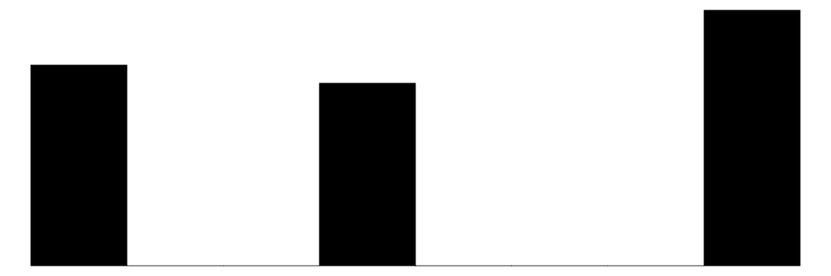

disp

28

0

228.1

118.7

71.1

200.0

472.0

[figure not shown]

hp

23

0

142.7

66.8

52.0

113.0

335.0

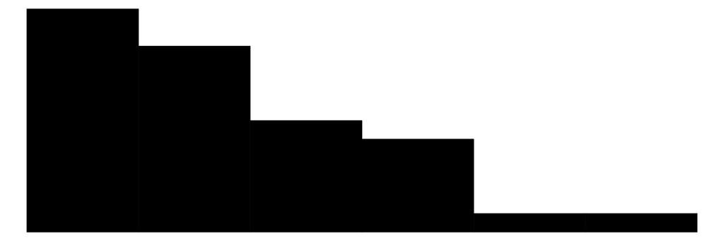

drat

23

0

3.6

0.5

2.8

3.6

4.9

[figure not shown]

wt

31

0

3.3

1.3

1.5

3.2

8.0

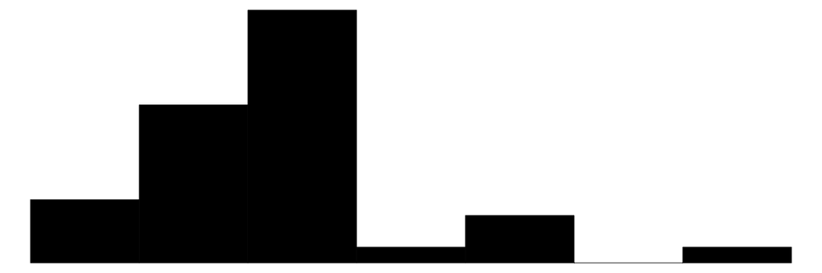

qsec

31

0

17.7

1.8

14.5

17.4

22.9

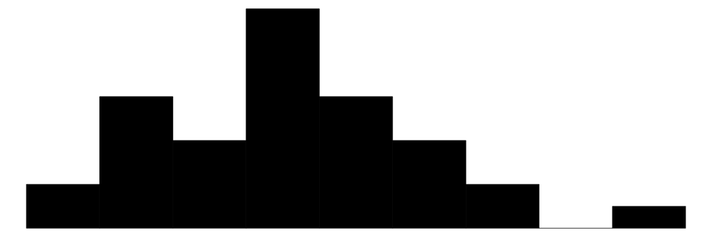

vs

2

0

0.4

0.5

0.0

0.0

1.0

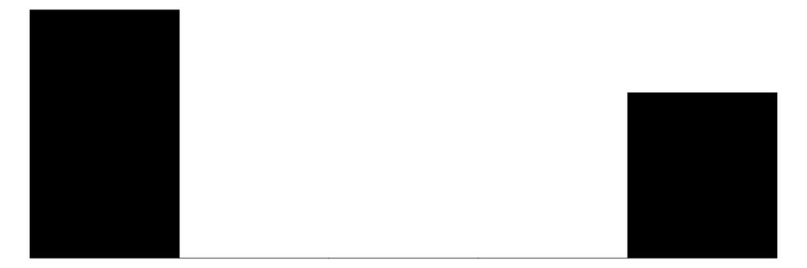

am

2

0

0.5

0.5

0.0

0.0

1.0

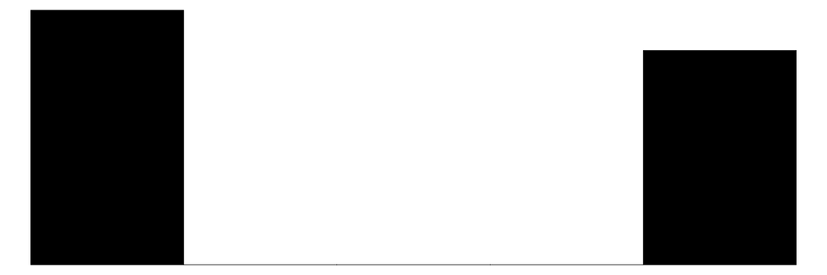

gear

3

0

3.7

0.7

3.0

4.0

5.0

[figure not shown]

carb

6

0

2.7

1.6

1.0

2.0

8.0

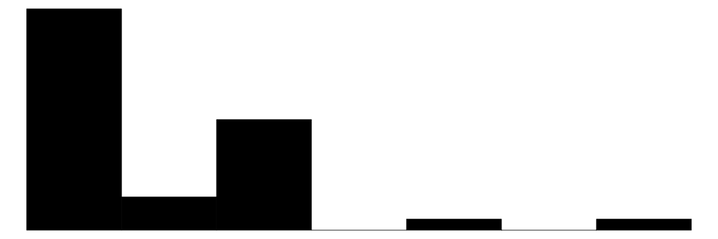

I have no idea what I’m looking for here.

However, just because we don’t see any extreme values in the summary statistics doesn’t mean we don’t have outliers that could be influential in our regression models. We need to dig a little deeper.

### Univariate Approaches to Outlier Detection

Sometimes it’s useful to start by looking at individual variables to see if anything unusual is going on. Histograms can give us a quick visual sense of the distribution, but box plots are generally better for identifying outliers. As you know, the box plot shows the five-number summary; the box encompasses the middle 50% of the data, with a line at the median. Any observations beyond the whiskers appear as individual points. These are potential outliers. I’ll make a little pipe here to show the boxplots in a single figure below.

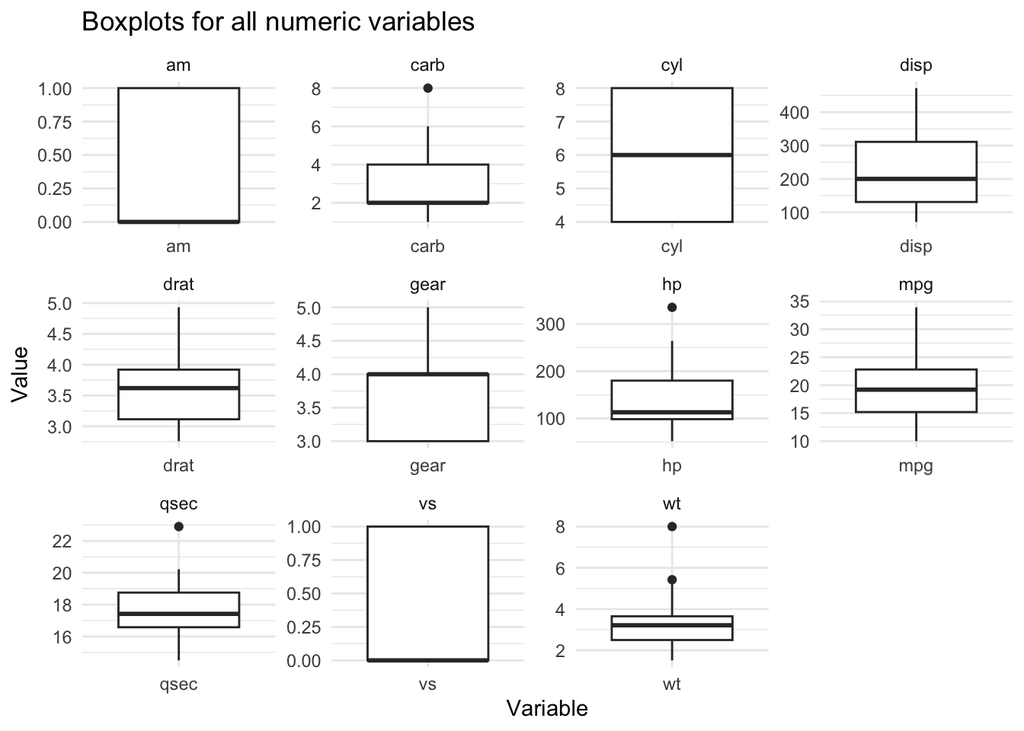

```r
# boxplots for each numeric variable

carz %>%
  select(where(is.numeric)) %>%
  pivot_longer(cols = everything(), names_to = "variable", values_to = "value") %>%
  ggplot(aes(x = variable, y = value)) +
  geom_boxplot() +
  facet_wrap(~ variable, scales = "free") + # 'scales = "free"' allows each plot to have its own y-axis scale
  labs(title = "Boxplots for all numeric variables", x = "Variable", y = "Value") +
  theme_minimal()
```

We do see a few dots in this plot. This means that several of our variables might have individual points that are far from the mass of values for the variable. Of course, seeing these doesn’t mean we’ve got a problem with outliers, just as seeing no individual points doesn’t mean we’re in the clear.

Why? Is it because problematic outliers are often bivariate or multivariate outliers?

Exactly right! As we learned from our simulation, influential outliers are often bivariate in nature. An observation might not be unusual on any single variable, but the combination of its X and Y values (or its pattern across multiple X variables) might make it an outlier in the context of our regression model. This is why we need regression-based diagnostics. So let’s push forward.

### Studentized Residuals

One of the most straightforward approaches to detecting outliers in regression is to examine the studentized residuals. A studentized residual is a residual that has been standardized by an estimate of its standard deviation. We typically look for observations with studentized residuals greater than 3 or less than -3 (i.e., more than three standard deviations from zero).

Let’s estimate a model:

```r
# estimate the model
ols.fit <- lm(mpg ~ wt + hp + cyl, data = carz)
modelsummary(ols.fit, stars = TRUE, gof_omit = "AIC|BIC|Log|Deviance")
```

|  | (1) |
| --- | --- |
| (Intercept) | 36.583*** |
|  | (3.067) |
| wt | 0.641 |
|  | (0.740) |
| hp | -0.007 |
|  | (0.020) |
| cyl | -2.905** |
|  | (0.860) |
| Num.Obs. | 35 |
| R2 | 0.579 |
| R2 Adj. | 0.538 |
| RMSE | 4.14 |

+ p < 0.1, * p < 0.05, ** p < 0.01, *** p < 0.001

Great. Now let’s take a look at the studentized residuals.

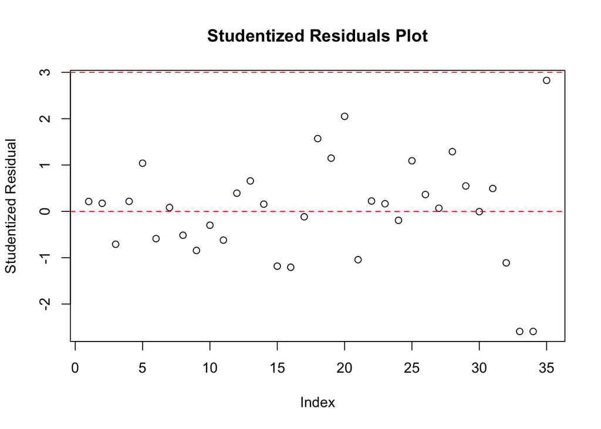

```r
# Get the studentized residuals
res.std <- rstudent(ols.fit)

# Plot them and add lines to identify extreme values
plot(res.std, ylab = "Studentized Residual",
     main = "Studentized Residuals Plot")
abline(h = c(-3, 0, 3), lty = 2, col = "red")
```

```r
# Identify potentially problematic observations
index <- which(res.std > 3 | res.std < -3)
print(index) # observations with possible problematic outliers
```

```
## named integer(0)
```

We don’t see any observations here that fall outside the ±3 range, but there’s a few that are probably pretty close to this. These are potential outliers that warrant further investigation. However, we need to remember that not all of these will be influential outliers—some might just be regular outliers with unusual Y values but typical X values.

Whew. So we don’t need to be worried yet?

No, we don’t need to be worried yet. And, frankly, this isn’t really something to get too stressed out about. We’ll be able to deal with whatever comes to us. But first we need to better understand what we’re facing.

We can also use the `outlierTest()` function from the `car` package, which tests whether the largest studentized residual (in our plot above, it looks like this will be car number 35) is significantly different from the others using a Bonferroni correction:

```r
car::outlierTest(ols.fit)
```

```
## No Studentized residuals with Bonferroni p < 0.05
## Largest |rstudent|:
##    rstudent unadjusted p-value Bonferroni p
## 35    2.827           0.008294       0.2903
```

The Bonferroni correction adjusts the p-value to account for the fact that we’re conducting multiple tests (one for each observation). This helps protect against false positives when testing many observations simultaneously. In this case, we fail to reject the null hypothesis that there are no outliers in the model, suggesting that while some observations have large residuals, they may not be statistically significant outliers once we account for multiple testing.

Okay, but doesn’t this just tell us about observations with unusual $Y$ values? What about influential outliers that might have typical $Y$ values but unusual $X$ values?

Exactly. This gives us a sense of the observations where our regression doesn’t do a good job of predicting the Y value (i.e., the residual is large), but it doesn’t tell us about observations that might be influential because of their X values. For that, we need to look at other diagnostics, like Cook’s Distance.

### Diagnostic Plots

My starting point for evaluating my model for problematic outliers usually starts with the standard diagnostic plots. The standard diagnostic plots from base R can also help us identify influential outliers. The fourth plot (Residuals vs. Leverage) is particularly useful for this purpose:

Figure 2: Diagnostic Plots

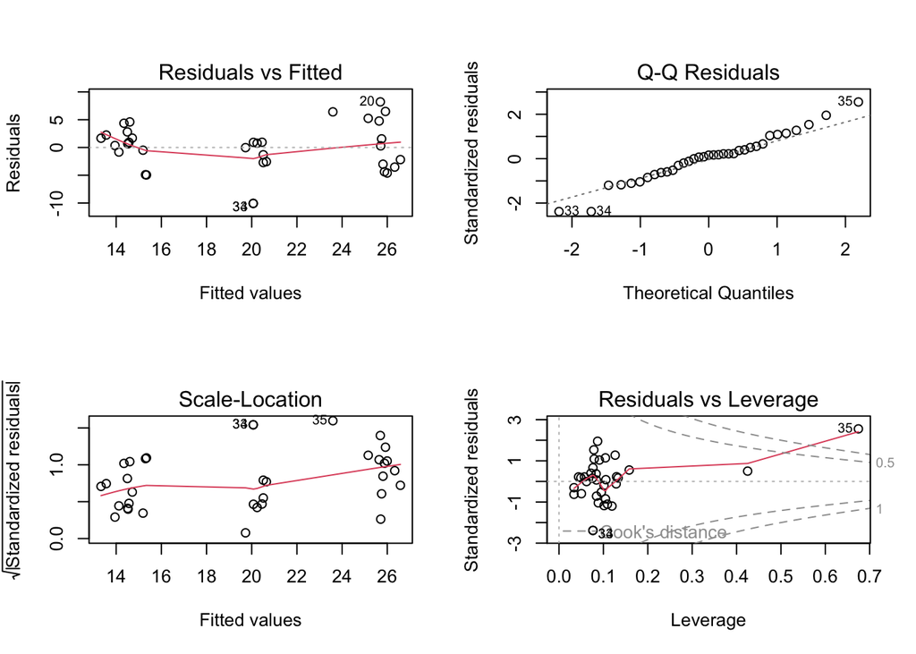

```r
par(mfrow = c(2, 2))
plot(ols.fit)
```

These plots are a good place to start when trying to get a sense of how are model fares vis-a-vis the OLS model assumptions. We can get a rough sense of the distribution of our error term, whether we’ve got patterns in our error term, etc. But the one we’re most interested in for outlier detection is the Residuals vs. Leverage plot (bottom right). This plot shows us the relationship between the residuals and the leverage of each observation. Here, we’re looking for observations in the upper or lower right corners, outside the dashed Cook’s Distance contour lines. These would represent high-leverage points that also have large residuals—exactly the definition of influential outliers. In our case, we’ve got a few outliers here, one of which is in the Cook’s Distance danger zone.

Wait. Who is Cook? What is his “distance”?

I see what you’re doing here. You’re trying to get me off track. If you really need to know who Cook is, you can check out [his website](http://users.stat.umn.edu/~rdcook/) or his [Wikipedia page](https://en.wikipedia.org/wiki/R._Dennis_Cook) if you truly must know. But the important thing is that Cook’s Distance is a measure of how much an observation influences our regression estimates. Unlike studentized residuals, which only tell us about observations with unusual Y values, Cook’s Distance tells us about observations that actually influence our regression estimates.

For each observation $i$, Cook’s $D_i$ measures the effect of deleting that observation on the regression coefficients. It’s calculated as:

$$D_{i}={\frac {\sum _{j=1}^{n}\left({\widehat {y}}_{j}-{\widehat {y}}_{j(i)}\right)^{2}}{ks^{2}}}$$

Figure 3: Cook’s Distance

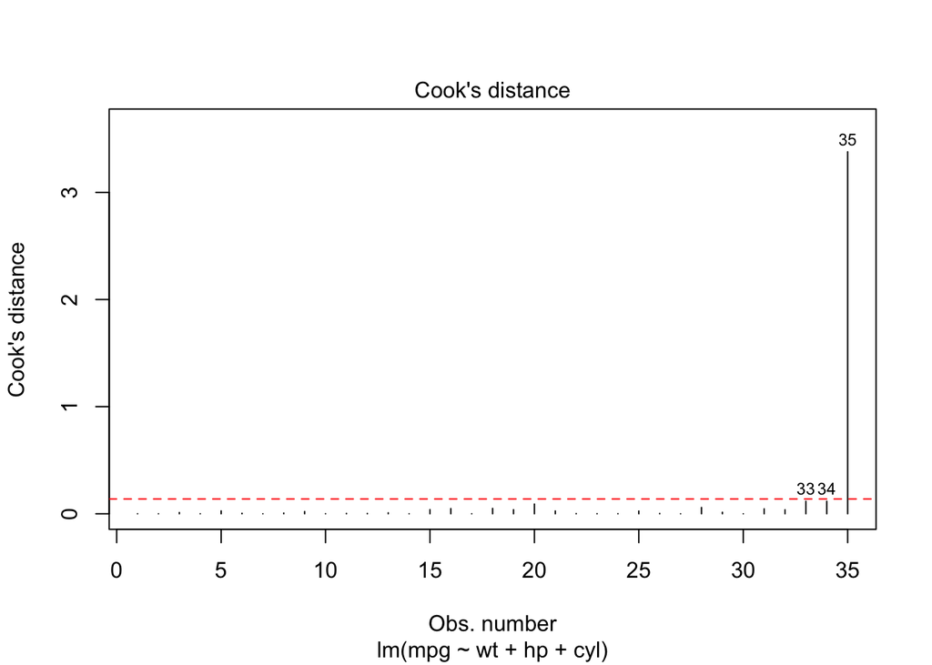

```r
# Calculate the cutoff
cutoff <- 4/((nrow(carz) - length(ols.fit$coefficients) - 2))

# Plot Cook's Distance
plot(ols.fit, which = 4, cook.levels = cutoff)
abline(h = cutoff, lty = 2, col = "red")
```

Oof. So it looks like we may have some issues here. Observations number 33, 34, and (especially) 35 look a bit suspect. The `car` package also provides a helpful influence plot that combines several diagnostics. Let’s check that one out and see what it looks like.

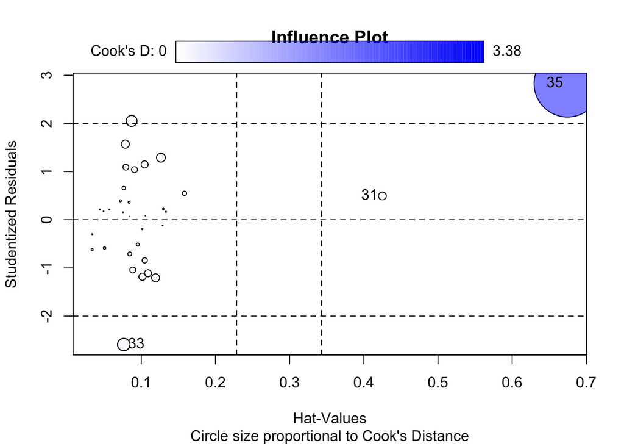

```
##    StudRes     Hat   CookD
## 31  0.4943 0.42503 0.04628
## 33 -2.5910 0.07639 0.11721
## 35  2.8266 0.67461 3.37923
```

```r
influencePlot(ols.fit,
              main = "Influence Plot",
              sub = "Circle size proportional to Cook's Distance")
```

This plot shows studentized residuals on the y-axis and hat values (a measure of leverage) on the x-axis, with the size of each point proportional to Cook’s Distance. This is similar to the last plot in our standard diagnostic plots, in that our most problematic observations will generally be in one of the corners on the right side of the plot. These are the ones with both high leverage and large residuals. The bubbles represent how influential each of the observations are (measured, of course, using Cook’s D). We see here that most of the bubbles look to be white, but one of them is huge and blue. This is a sign that we’ve got a very high Cook’s distance measure.

So now is it time to get worried?

This seems bad, and it might be a little bad. Thankfully, we’ve got all sorts of different ways to deal with these issues. Let’s explore some of them.

## What To Do About Outliers

Once you’ve identified outliers in your data, you have several options:

1. drop them
2. dummy them out
3. Windsorize them
4. use robust regression methods

### Dropping Outliers

The most straightforward way to deal with influential outliers is to just drop them from the analysis. This is a great way to deal with outliers that are the result of data entry errors or other mistakes.

This sounds easy. Why not just do this all the time?

This sounds easy because it is. But it’s not without its drawbacks. The decision to remove outliers should be driven by substantive considerations, not just statistical ones. Sometimes outliers represent important and real variation in your data. Removing them might make your model fit better statistically, but it could also mean you’re ignoring important parts of the story your data are telling. The key is to understand where your outliers come from, investigate them carefully, and make decisions that are transparent and well-justified.

Let’s see what that looks like in our example:

```r
influential_obs <- 35
carz_drop <- carz[-influential_obs, ]

drop.fit <- lm(mpg ~ wt + hp + cyl, data = carz_drop)

modz <- list(Original = ols.fit,
             Dropped = drop.fit)

modelsummary(modz,
             stars = TRUE, gof_omit = "AIC|BIC|Log|Deviance")
```

|  | Original | Dropped |
| --- | --- | --- |
| (Intercept) | 36.583*** | 38.128*** |
|  | (3.067) | (2.824) |
| wt | 0.641 | -1.964+ |
|  | (0.740) | (1.139) |
| hp | -0.007 | 0.002 |
|  | (0.020) | (0.018) |
| cyl | -2.905** | -2.048* |
|  | (0.860) | (0.834) |
| Num.Obs. | 35 | 34 |
| R2 | 0.579 | 0.640 |
| R2 Adj. | 0.538 | 0.604 |
| RMSE | 4.14 | 3.73 |

+ p < 0.1, * p < 0.05, ** p < 0.01, *** p < 0.001

So, dropping the influential observation has a pretty big impact on our coefficient estimates. The coefficient for `wt` changes from 0.641 (not significant) to -1.964 (almost significant). There are some additional changes to the model estimates, as well. The model seems to predict more of the variance in `mpg` than the original did. This is a good example of how influential outliers can bias our estimates and lead us to different conclusions about the relationships in our data.

Does this clear up our outlier problem?

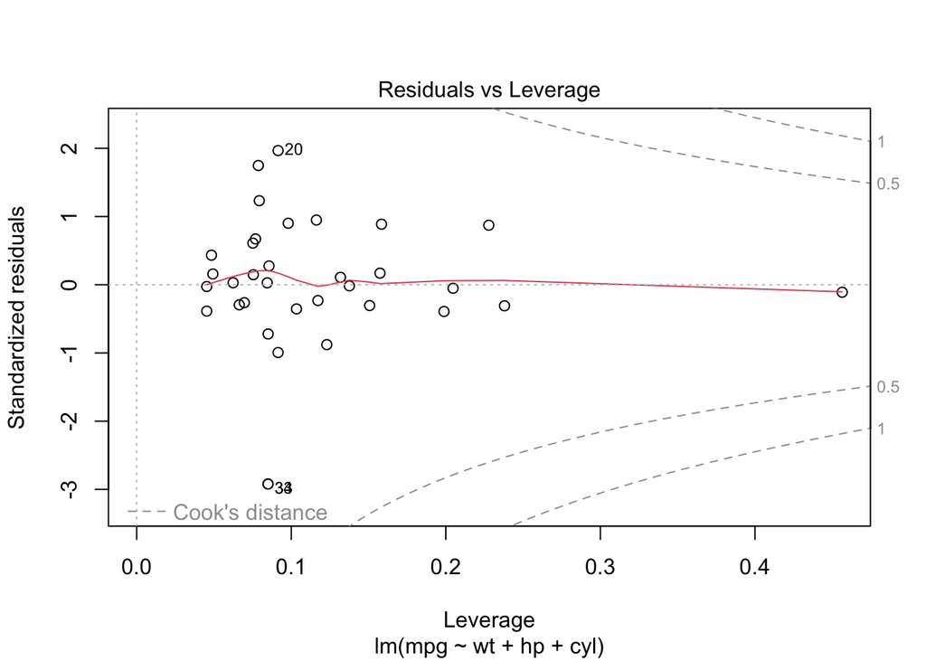

```r
plot(drop.fit, which = 5)
```

Yay! This looks much better. So we’re done here, then?

Not so fast. In our example, we *know* that the influential observation is a problem because we added it in ourselves. In real data, we won’t have this luxury. We need to be careful about how we handle outliers, and we need to be transparent about our decisions. If we didn’t already know that this outlier didn’t represent something real about our data, we’d best look for an alternative option.

### Dummying Outliers

Another option is to create a dummy variable that indicates whether an observation is an outlier. This allows us to keep the outlier in the analysis while controlling for its influence. This can be a good option when we have reason to believe the outlier represents a real phenomenon that we want to account for in our model.[^1] Doing this creates a new intercept for the outlier observation. Sometimes this can work if you have more than one outlier, provided they all have something relevant in common with each other that makes them different from the others. As with dropping outliers, dummying our outliers out should also be done with some real thought about what those observations actually represent.

To accomplish this, we’ll just need to create a new dummy variable where our outlier is 1 and the other observations are 0. Then we can include this in our regression model to give us a new intercept for the outlier observation. This allows us to control for the influence of the outlier without removing it from the analysis.

```r
carz <- carz %>%
  mutate(outlier = ifelse(
    row_number() == influential_obs, 1, 0))

dummy.fit <- lm(mpg ~ wt + hp + cyl + outlier, data = carz)

# add to list of models

modz <- append(modz, list(Dummy = dummy.fit))

modelsummary(modz,
             stars = TRUE, gof_omit = "AIC|BIC|Log|Deviance")
```

|  | Original | Dropped | Dummy |
| --- | --- | --- | --- |
| (Intercept) | 36.583*** | 38.128*** | 38.128*** |
|  | (3.067) | (2.824) | (2.824) |
| wt | 0.641 | -1.964+ | -1.964+ |
|  | (0.740) | (1.139) | (1.139) |
| hp | -0.007 | 0.002 | 0.002 |
|  | (0.020) | (0.018) | (0.018) |
| cyl | -2.905** | -2.048* | -2.048* |
|  | (0.860) | (0.834) | (0.834) |
| outlier |  |  | 19.694** |
|  |  |  | (6.967) |
| Num.Obs. | 35 | 34 | 35 |
| R2 | 0.579 | 0.640 | 0.667 |
| R2 Adj. | 0.538 | 0.604 | 0.623 |
| RMSE | 4.14 | 3.73 | 3.68 |

+ p < 0.1, * p < 0.05, ** p < 0.01, *** p < 0.001

Let’s check the plot to see how we did.

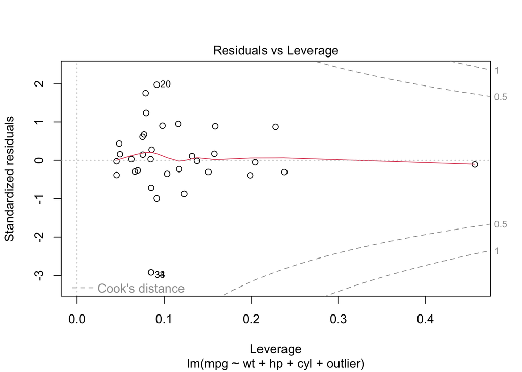

```r
plot(dummy.fit, which = 5)
```

This seems like a good option. There must be a catch, right?

Of *course* there’s a catch! The catch is that this approach only works well when you have a small number of outliers that share something in common. If you have a large number of outliers, or if they don’t share any common characteristics, then this approach can become unwieldy and may not be the best choice. Additionally, if the outlier is truly influential, it may still bias your estimates even with the dummy variable included. So while this can be a good option in some cases, it’s not a one-size-fits-all solution. But we do have more options.

### Winsorizing Outliers

If we have values that are far outside the typical range in our data, we might want to consider truncating those values. This is exactly what Winsorizing is.

Wait, what is Winsorizing? Is that a real word?

Yes. It’s a real world named after a real person (who is not the King of England). The Winsorizing process was named for Charles Winsor, who has [a Wikipedia page](https://en.wikipedia.org/wiki/Charles_Winsor) (but not his own website for reasons you will figure out when you check Wikipedia). Winsorizing is a simple but clever technique where we replace extreme values with the value associated with a specified percentile of the data. For example, we might replace any value above the 95th percentile with the value at the 95th percentile. This can help reduce the influence of outliers while still keeping them in the analysis. However, this approach can also be somewhat arbitrary and may not always be appropriate, especially if the outliers represent real phenomena that we want to understand.

Doing this by hand is a little fussy. Thankfully, we can accomplish this using the `descTools::Winsorize()` or the `psych::winsor()` function. Both allow us to specify the limits for Winsorizing our data. For example, if we want to Winsorize our `wt` variable at the 5th and 95th percentiles, we can do it like this:

```r
carz <- carz %>%
  mutate(wt_w = psych::winsor(wt, trim = 0.05))

winsor.fit <- lm(mpg ~ wt_w + hp + cyl, data = carz)

modz <- append(modz, list(Winsorized = winsor.fit))

modelsummary(modz,
             stars = TRUE,
             gof_omit = "AIC|BIC|Log|Deviance")
```

|  | Original | Dropped | Dummy | Winsorized |
| --- | --- | --- | --- | --- |
| (Intercept) | 36.583*** | 38.128*** | 38.128*** | 36.950*** |
|  | (3.067) | (2.824) | (2.824) | (3.157) |
| wt | 0.641 | -1.964+ | -1.964+ |  |
|  | (0.740) | (1.139) | (1.139) |  |
| hp | -0.007 | 0.002 | 0.002 | -0.008 |
|  | (0.020) | (0.018) | (0.018) | (0.020) |
| cyl | -2.905** | -2.048* | -2.048* | -2.585** |
|  | (0.860) | (0.834) | (0.834) | (0.913) |
| outlier |  |  | 19.694** |  |
|  |  |  | (6.967) |  |
| wt_w |  |  |  | -0.001 |
|  |  |  |  | (1.094) |
| Num.Obs. | 35 | 34 | 35 | 35 |
| R2 | 0.579 | 0.640 | 0.667 | 0.569 |
| R2 Adj. | 0.538 | 0.604 | 0.623 | 0.527 |
| RMSE | 4.14 | 3.73 | 3.68 | 4.19 |

+ p < 0.1, * p < 0.05, ** p < 0.01, *** p < 0.001

So this one looks quite different from the others. The goodness-of-fit statistics are closest to our original model. The parameter estimate for the `wt_w` variable is quite a bit different from what it is in the other models. This is because the Winsorizing process has reduced the influence of the outlier on our estimates. The parameter estimates for `hp` and `cyl` are also different from the original model, but they are more similar to the original than they are in the other models. This is because we haven’t completely tossed the outlier from the estimation of the rest of the parameter estimates; we’ve only dampened its influence on them.

This seems like a pretty good option. Why not just do this all the time?

This can be a good option in some cases, but it’s not without its drawbacks. The main issue with Winsorizing is that it can be somewhat arbitrary. The choice of which percentiles to use for Winsorizing can have a big impact on your results, and there’s no one-size-fits-all answer for which percentiles to use. Additionally, if the outliers represent real phenomena that we want to understand, then Winsorizing might not be the best choice because it can obscure important information in the data.

### Robust Regression Methods

Finally, if we have a lot of outliers or if we want to be more systematic about dealing with them, we might consider using robust regression methods. These methods are designed to be less sensitive to outliers than ordinary least squares regression. One common approach is to use M-estimators, which downweight the influence of outliers in the estimation process.

How is this different from Winsorizing?

You’re right that the logic is similar in that both approaches aim to reduce the influence of outliers on our estimates. However, robust regression methods do this in a more systematic way by adjusting the estimation process itself, rather than just modifying the data. Robust regression methods can be more flexible and can provide better estimates in the presence of outliers, especially when there are many outliers or when the outliers are not easily identifiable. Basically, it uses an iterative process to create a weighted regression where the weights are determined by the residuals. Observations with large residuals (potential outliers) receive smaller weights, which reduces their influence on the parameter estimates. This allows us to get more reliable estimates even when our data contains outliers.

The `MASS` package provides a convenient function called `rlm()` for fitting robust linear models using M-estimators. Here’s how we can use it:

```r
robust.fit <- MASS::rlm(mpg ~ wt + hp + cyl, data = carz)

modz <- append(modz, list(Robust = robust.fit))

modelsummary(modz,
             stars = TRUE,
             gof_omit = "AIC|BIC|Log|Deviance")
```

|  | Original | Dropped | Dummy | Winsorized | Robust |
| --- | --- | --- | --- | --- | --- |
| (Intercept) | 36.583*** | 38.128*** | 38.128*** | 36.950*** | 36.149*** |
|  | (3.067) | (2.824) | (2.824) | (3.157) | (2.305) |
| wt | 0.641 | -1.964+ | -1.964+ |  | -1.081+ |
|  | (0.740) | (1.139) | (1.139) |  | (0.556) |
| hp | -0.007 | 0.002 | 0.002 | -0.008 | -0.014 |
|  | (0.020) | (0.018) | (0.018) | (0.020) | (0.015) |
| cyl | -2.905** | -2.048* | -2.048* | -2.585** | -1.763* |
|  | (0.860) | (0.834) | (0.834) | (0.913) | (0.646) |
| outlier |  |  | 19.694** |  |  |
|  |  |  | (6.967) |  |  |
| wt_w |  |  |  | -0.001 |  |
|  |  |  |  | (1.094) |  |
| Num.Obs. | 35 | 34 | 35 | 35 | 35 |
| R2 | 0.579 | 0.640 | 0.667 | 0.569 |  |
| R2 Adj. | 0.538 | 0.604 | 0.623 | 0.527 |  |
| RMSE | 4.14 | 3.73 | 3.68 | 4.19 | 4.50 |

+ p < 0.1, * p < 0.05, ** p < 0.01, *** p < 0.001

Where did the $R^2$ go? Why is it not in the table?

Good catch! The `rlm()` function from the `MASS` package does not provide an $R^2$ value because it’s not based on the same assumptions as ordinary least squares regression. Robust regression methods focus on providing reliable parameter estimates in the presence of outliers, but they don’t necessarily fit the data in the same way as OLS, which is why traditional goodness-of-fit measures like $R^2$ aren’t applicable. Instead, we can look at other diagnostics and measures of fit that are more appropriate for robust regression models to evaluate how well our model is performing. For a deeper discussion of this method, see Chapter 19 in Fox (2016).

Let’s see what the diagnostic plot looks like:

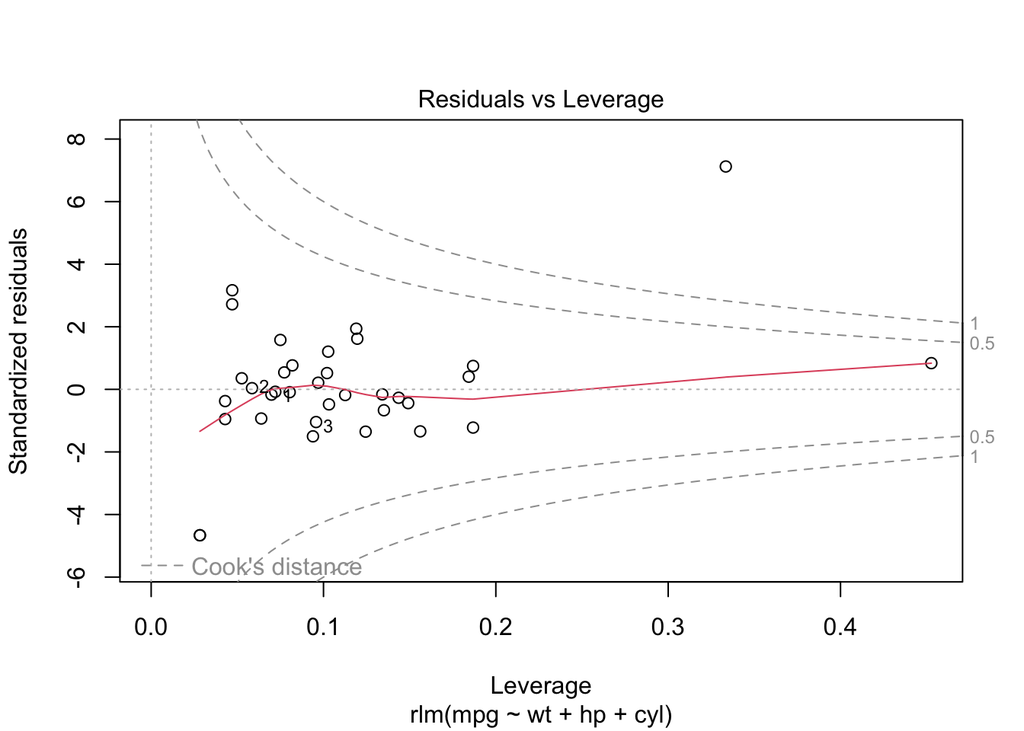

```r
plot(robust.fit, which = 5)
```

I’m so confused. Why don’t you just tell me which one is best?

I know. I’m sorry. But there really isn’t a single best method for dealing with influential outliers. The best approach depends on the context of your analysis, the nature of your data, and the specific research questions you’re trying to answer. Each method has its own advantages and disadvantages, and the choice of which one to use should be guided by substantive considerations about what the outliers represent in your data.

There are, however, a few tips that might help you make this decision.

- If the outliers are the result of data entry errors or other mistakes, then dropping them from the analysis is often the best option.
- If you have a small number of outliers that represent a real phenomenon that we want to understand, then dummying them out allows you to capture something about how these cases differ from the others, perhaps even making your theory more nuanced.
- If you have more than just a few observations that are outliers on a specific variable (that don’t have an obvious, theoretically relevant characteristic in common), then Winsorizing can be a good option.
- If you have a lot of outliers across a number of different combinations of variables and/or if you want to be more systematic about dealing with them, then robust regression methods can provide more reliable estimates in the presence of outliers.

Outliers are a fact of life in real-world data analysis. Not all outliers are problematic—regular outliers and even some high-leverage points can be perfectly fine to include in your models. The outliers we need to worry about are influential observations that bias our coefficient estimates.

The diagnostic tools we’ve covered—–studentized residuals, Cook’s Distance, and diagnostic plots—–give us multiple ways to identify potentially problematic observations. But identification is just the first step. The real work lies in understanding where these outliers come from and making thoughtful decisions about how to handle them in your analysis.

## In MLE and Bayesian Estimation

Many folks think that outliers are only a problem for OLS regression, but that’s not the case. Outliers can also be problematic in maximum likelihood estimation (MLE) and Bayesian estimation.

Oh, no. Not this again!

I know. But I promise to keep things as simple as I can. Let’s take this one step at a time. We’ll start with MLE.

### In MLE

MLE with a Gaussian likelihood minimizes the same squared deviations as OLS — because the Gaussian log-likelihood is a quadratic function of the residuals. So influential outliers distort the MLE estimates for exactly the same reason they distort OLS: the squared loss function penalizes large deviations heavily, and a single extreme observation can pull the estimated surface disproportionately. There is no robustness “for free” just because you wrote down a likelihood.

As with OLS, the key distinction is between outliers (unusual in Y-space) and high-leverage points (unusual in X-space). Both are dangerous; high-leverage points are often more insidious because they don’t necessarily produce large residuals. In MLE, outliers can lead to biased parameter estimates and can affect the convergence of the optimization algorithm.

So can we just use the same diagnostics as OLS?

Sort of. Let’s start by looking at the tools that work with `glm` objects. First, let’s look at the basic diagnostic plots for our MLE model:

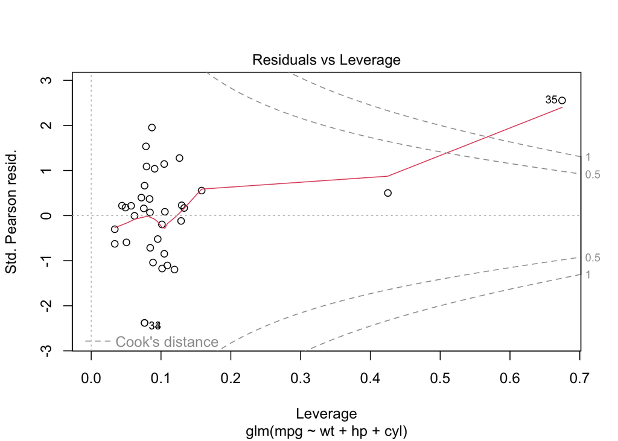

```r
# estimate model using MLE
mle.fit <- glm(mpg ~ wt + hp + cyl,
               data = carz,
               family = gaussian(link = "identity")
)

plot(mle.fit, which = 5)
```

It might come as a surprise to learn that the same diagnostic plots we use for OLS can be used for MLE models as well. The logic is the same: we’re looking for observations with large residuals and high leverage. The interpretation of these plots is also the same as in OLS.

Wait. I thought that MLE doesn’t have residuals! How is this even working?

This is a very clever insight. First, it’s important to realize that, while MLE doesn’t obsess over residuals the way OLS does, these models *do* have residuals. It’s just that these models don’t have assumptions about the distribution of these residuals (as OLS does). In a Gaussian MLE model, the residuals are just the differences between the observed values and the predicted values from the model. The diagnostic plots for MLE models are based on these residuals, so we can still use them to identify potential outliers and influential observations.

What MLE estimation removes is the theoretical guarantee derived from Gauss-Markov that gives OLS residuals their specific distributional properties. But the residuals (i.e., the raw differences between observed and predicted values, or $\hat{y}_i-y_i$) still exist, and they can still be used to identify outliers. The diagnostic plots for MLE models are based on these residuals, so we can still use them to identify potential outliers and influential observations.

If follows from this that we can also calculate Cook’s Distance for our MLE model to identify influential observations. None of these diagnostics is really about the error term per se; instead, they’re about the geometry of the design matrix. In other words, it’s about how much each individual observation is pulling the estimated coefficients toward itself. Cook’s distance measures how much the coefficient vector $\hat{\beta}$ shifts when you delete observation $i$ and refit. That’s a question about estimation stability, not about distributional assumptions. It will reveal influential points regardless of whether you estimated by OLS, MLE, or anything else that produces a $\hat{\beta}$.

So these diagnostics are asking questions about the data’s relationship to the model, not about the model’s assumptions about the data?

When we’re talking about MLE, that’s exactly right. And the linear model is a special case of MLE that has even more similarities with OLS compared to the models we’ll learn about in PSC 703. In this special case, the MLE solution is algebraically identical to OLS. The likelihood surface is quadratic in $\beta$, and maximizing it produces *exactly* the normal equations we use to calculate OLS coefficients. In other words, the MLE residuals aren’t just analogous to OLS residuals; they *are* OLS residuals.

Woah. So does that mean that the same strategies for finding and dealing with outliers in OLS will work for MLE as well?

Yes. Mostly. Studentized residuals can be calculated for MLE models, but they aren’t really analogous to the studentized residuals we get from OLS because they don’t have the same distributional properties. However, our most helpful tool (Cook’s Distance) can be calculated for MLE models and can be used to identify influential observations. The diagnostic plots for MLE models are based on the residuals, so we can still use them to identify potential outliers and influential observations, as we saw in the diagnostic plot above.

However, there is a way to use the other tools (like `car::influencePlot()` and studentized residuals) with MLE models as well. The simplest way is to just estimate your model using `lm()` instead.

Wait. What? You’re kidding. All of this babbling on and on just to tell me that I should just diagnose an OLS version of the model after all?

Yeah. But the adjustments you make to your model to deal with outliers will still be relevant for your MLE model. The diagnostics are really about the geometry of the design matrix and the influence of individual observations on the estimated coefficients, rather than about the specific estimation method. So, by diagnosing an OLS version of your model, you can identify influential observations and then apply the appropriate adjustments (like dropping, dummying, Winsorizing, or using robust regression methods) to your MLE model as well. To avoid breaking your brain, we’ll skip the discussion of estimating robust MLE models. But the strategies of dropping, dummying, and Winsorizing can all be applied to MLE models just as they can be applied to OLS models.

### In BE

In Bayesian estimation, outliers can influence the posterior distribution and lead to biased estimates as well. The same diagnostic tools we use for OLS can be adapted for use in MLE and Bayesian contexts, and similar strategies for dealing with outliers can be applied.

You’re not going to tell me to just estimate an OLS version and diagnose *that*, are you?

Mostly, yes. That’s exactly what I’m going to do. The same logic applies here as it does in MLE. The diagnostic tools for identifying influential observations are based on the geometry of the design matrix and the influence of individual observations on the estimated coefficients, rather than on the specific estimation method. So, by diagnosing an OLS version of your model, you can identify influential observations and then apply the appropriate adjustments to your Bayesian model as well.

There is one cool thing about BE models that can really demonstrate the influence of outliers. Let’s walk through our example and see.

After fitting our model, we can use `loo::loo()` to perform leave-one-out cross-validation and identify influential observations based on their contribution to the expected log predictive density (ELPD). Observations with large negative contributions to ELPD are potential outliers that are influencing our model’s predictions. When you do approximate LOO with PSIS (Pareto-smoothed importance sampling, which is what `loo::loo()` does), each observation gets a Pareto shape parameter $k$. When $k > 0.7$, the approximation breaks down because that observation is so influential that the posterior shifts dramatically without it. This is a principled Bayesian way to flag the same observations Cook’s D would flag, and it emerges naturally from the Bayesian workflow rather than being bolted on afterward.

Let’s give it a try:

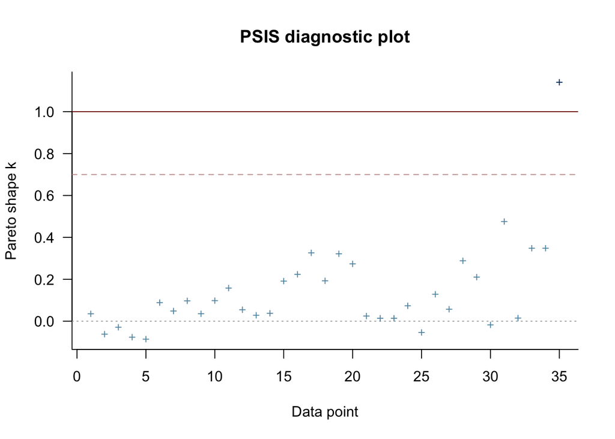

```r
loo.fit <- loo(bayes.fit)
plot(loo.fit)
```

What am I looking at?

Good question. This plot shows, for each observation, what happens to the posterior distribution when you remove that observation. Observations with $k > 0.7$ are flagged as influential. In our case, we see that observation number 35 has a $k$ value greater than 0.7, indicating that it is an influential observation that is affecting our model’s predictions. This is consistent with what we found using Cook’s Distance in our OLS diagnostics, which gives us confidence that this observation is indeed influential and warrants further investigation.

Aah. I see. So what do I actually *do* about the outliers?

As with MLE, most of the options for dealing with outliers work just as well with BE. Again, the exception here is robust regression methods, which are a bit more complicated to implement in a Bayesian context. However, the strategies of dropping, dummying, and Winsorizing can all be applied to Bayesian models just as they can be applied to OLS and MLE models. The key is to understand where your outliers come from and make thoughtful decisions about how to handle them in your analysis, regardless of the estimation method you’re using.

## References

Fox, John. 2016. *Applied Regression Analysis and Generalized Linear Models*. 3rd ed. SAGE Publications.

Gill, Rebecca D, Sylvia R Lazos, and Mallory M Waters. 2011. “Are Judicial Performance Evaluations Fair to Women and Minorities? A Cautionary Tale from Clark County, Nevada.” *Law & Society Review* 45 (3): 731759. https://doi.org/10.1111/j.1540-5893.2011.00449.

[^1]: This is something that happened in a paper I published a while back. In that paper (Gill et al. 2011), we were predicting evaluations of judges based on their performance and personal characteristics. One of our judges had been the subject of some truly gob-smacking scandals and was a pretty obviously unusual case. She also happened to be one of very few Latinas in our dataset, meaning that her extremely terrible behavior would contribute excessively to the overall parameter estimates for race and gender. Dummying her out was a pretty good option in that situation, since she was truly *sui generis*.